# Problems set 5

## Price Histograms with Facet and Color

[output not shown]

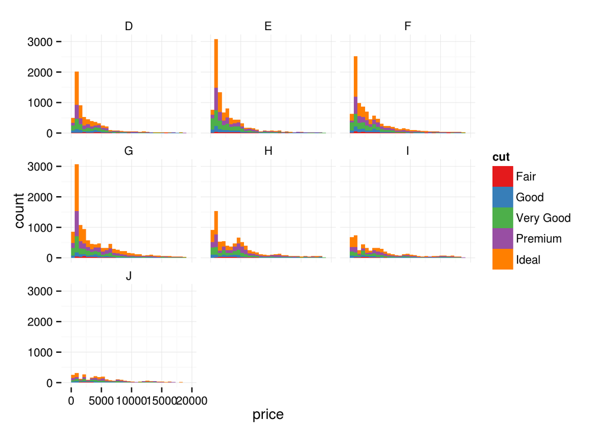

```r
library(ggplot2)
library(ggthemes)
theme_set(theme_minimal())
library(dplyr)
data(diamonds)

# Create a histogram of diamond prices.
# Facet the histogram by diamond color and use cut to color the histogram bars.

# The plot should look something like this. http://i.imgur.com/b5xyrOu.jpg

# Note: In the link, a color palette of type 'qual' was used to color the histogram using
# scale_fill_brewer(type = 'qual')
ggplot(aes(x = price), data = diamonds) +
  # other position values (fill, stack) look not better (or even worse)
  geom_histogram(aes(fill = cut), position = 'stack') +
  facet_wrap(~ color) +
  scale_fill_brewer("cut", type = 'qual', palette = "Set1")
```

Observations:

- H-I-J colors seems to present different distribution (bimodal) vs distribution of D-E-F-G colors. OTOH, this should be investigated, as the first impression might be false due to high spikes in D-G colors.
- ideal cut share is bigger in smaller price ranges (probably because they’re smaller diamonds and it’s hard to find big ideal diamond)

## Price vs. Table Colored by Cut

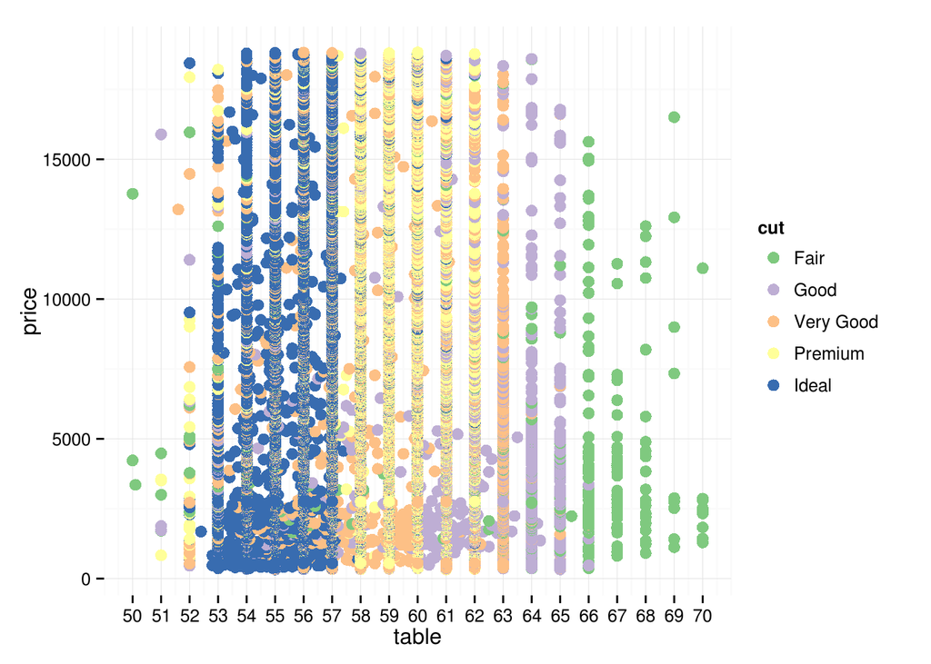

```r
# Create a scatterplot of diamond price vs. table and color the points by the cut of
# the diamond.

# The plot should look something like this.
# http://i.imgur.com/rQF9jQr.jpg
ggplot(aes(x = table, y = price), data = diamonds) +
  geom_point(aes(color = cut), size = 3) +
  # add scale and limits to see typical range easily
  scale_x_continuous(limits = c(50, 70), breaks=seq(50, 70, 1)) +
  scale_color_brewer("cut", type = 'qual', palette = 1)
```

Observations:

- there is most popular (preferred) range of table values 52-66.
- there seems to be no correlation between table and price
- cut is correlated with table (table goes up then cut goes from ideal to fair)

#### Typical table value

What is the typical table range for the majority of diamonds of IDEAL cut? 53-57

What is the typical table range for the majority of diamonds of PREMIUM cut? 58-62

## Price vs. Volume and Diamond Clarity

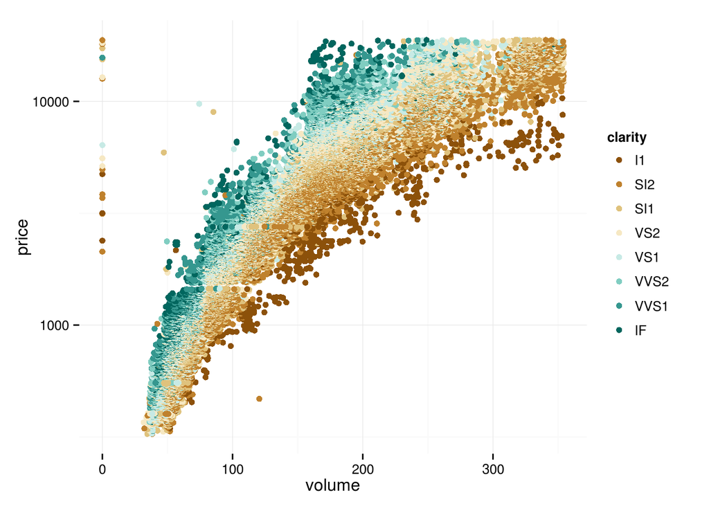

```r
# Create a scatterplot of diamond price vs. volume (x * y * z) and color the points by
# the clarity of diamonds.
# Use scale on the y-axis to take the log10 of price. You should also omit the top 1% of diamond volumes from the plot.

# Note: Volume is a very rough approximation of a diamond's actual volume.

# The plot should look something like this. http://i.imgur.com/excUpea.jpg

# Note: In the link, a color palette of type 'div' was used to color the scatterplot using
# scale_color_brewer(type = 'div')
diamonds$volume = diamonds$x * diamonds$y * diamonds$z
ggplot(aes(x = volume, y = price), data = subset(diamonds, volume < quantile(diamonds$volume, 0.99))) +
  geom_point(aes(color = clarity)) +
  scale_y_log10() +
  scale_color_brewer(type = 'div')
```

Observations:

- larger volume clearly affects the price
- better the clarity, higher the price of diamonds. Clarity is not as strong predictor as volume (on the log scale, the clarity adjusts the price to general trend coming from volume)
- there is less large diamonds (>250) with best clarities

## Proportion of Friendships Initiated

Many interesting variables are derived from two or more others.  
For example, we might wonder how much of a person’s network on a service like Facebook the user actively initiated. Two users with the same degree (or number of friends) might be very different if one initiated most of those connections on the service, while the other initiated very few. So it could be useful to consider this proportion of existing friendships that the user initiated. This might be a good predictor of how active a user is compared with their peers, or other traits, such as personality (i.e., is this person an extrovert?).

Your task is to create a new variable called ‘prop_initiated’ in the Pseudo-Facebook data set. The variable should contain the proportion of friendships that the user initiated.

```r
pf = read.delim('pseudo_facebook.tsv')
pf$prop_initiated = pf$friendships_initiated / pf$friend_count
```

## prop_initiated vs. tenure

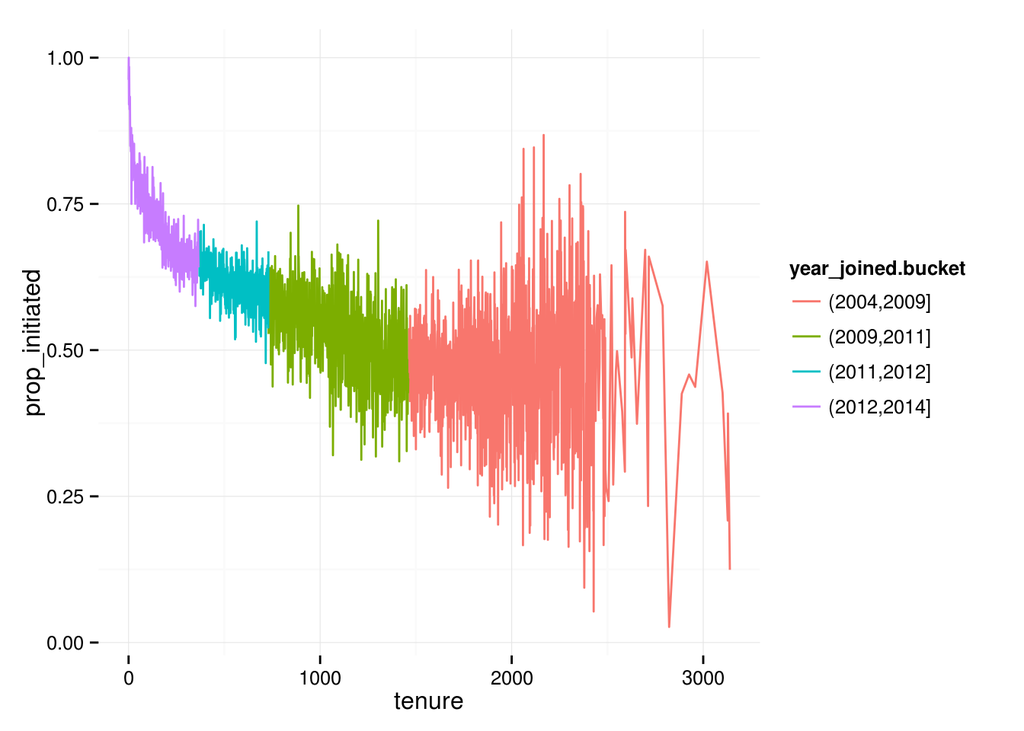

```r
# Create a line graph of
# the median proportion of friendships initiated ('prop_initiated') vs. tenure
# and color the line segment by year_joined.bucket.

# Recall, we created year_joined.bucket in Lesson 5
# by first creating year_joined from the variable tenure.
# Then, we used the cut function on year_joined to create
# four bins or cohorts of users.

# (2004, 2009]
# (2009, 2011]
# (2011, 2012]
# (2012, 2014]

# The plot should look something like this.
# http://i.imgur.com/vNjPtDh.jpg
# OR this
# http://i.imgur.com/IBN1ufQ.jpg
pf$year_joined <- 2014 - ceiling(pf$tenure / 365)
pf$year_joined.bucket <- cut(pf$year_joined, breaks = c(2004, 2009, 2011, 2012, 2014))
ggplot(aes(x = tenure, y = prop_initiated), data = pf) +
  geom_line(aes(color = year_joined.bucket), stat = 'summary', fun.y = median)
```

Observations:

- prop_initiated has the same trend, as friend_count. More mature (tenure) FB users are less active than the new ones.
- variability of the prop_initiated raises in time. Apparently, all new users (despite the character traits) are active ones, and the want to build up their friends network quickly. After the initial ‘storm’, the person character has stronger impact on how the person is active.
- clearly, people who joined after 2012 initiated the greated proportion of their FB friendships

## Smoothing prop_initiated vs. tenure

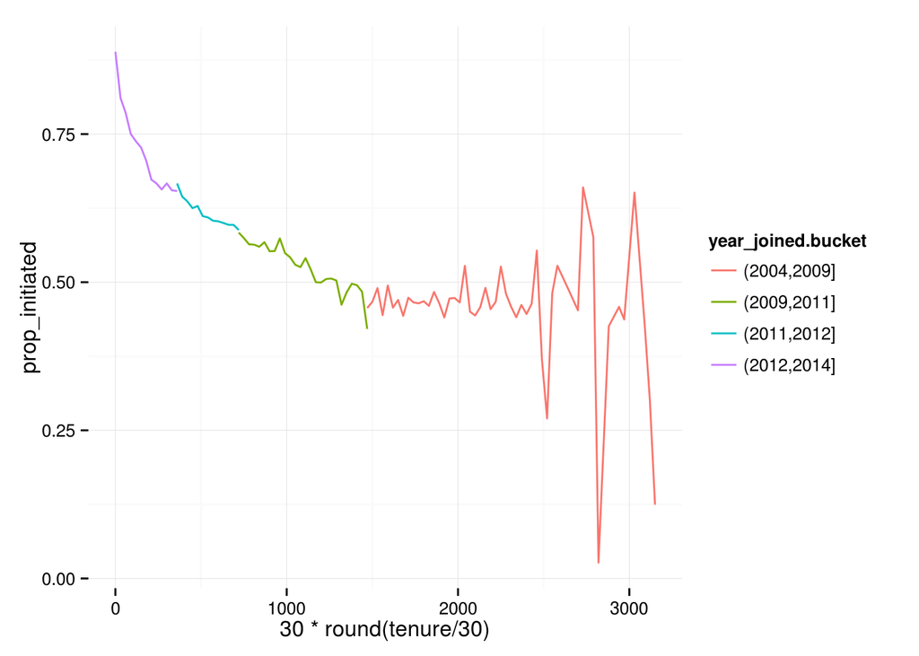

```r
# Smooth the last plot you created of of prop_initiated vs tenure colored by
# year_joined.bucket.
# You can bin together ranges of tenure or add a smoother to the plot.
ggplot(aes(x = 30 * round(tenure / 30), y = prop_initiated), data = pf) +
  geom_line(aes(color = year_joined.bucket), stat = 'summary', fun.y = median)
```

```
## geom_smooth: method="auto" and size of largest group is >=1000, so using gam with formula: y ~ s(x, bs = "cs"). Use 'method = x' to change the smoothing method.
```

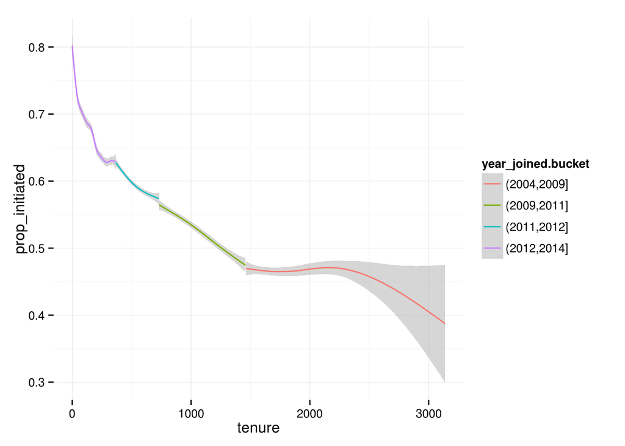

```r
ggplot(aes(tenure, y = prop_initiated), data = pf) +
  geom_smooth(aes(color = year_joined.bucket))
```

For the group with the largest propotion of the friendships initiated, what is the group’s average (mean) proportion of friendships initiaited?

```r
with(subset(pf, pf$year_joined.bucket == "(2012,2014]"), table(year_joined.bucket))
```

```
## year_joined.bucket
## (2004,2009] (2009,2011] (2011,2012] (2012,2014]
##           0           0           0       43658
```

```r
# 0.6653892
with(subset(pf, year_joined.bucket == "(2012,2014]"), mean(prop_initiated, na.rm=TRUE))
```

```
## [1] 0.6653892
```

## Price/Carat Binned, Faceted, & Colored

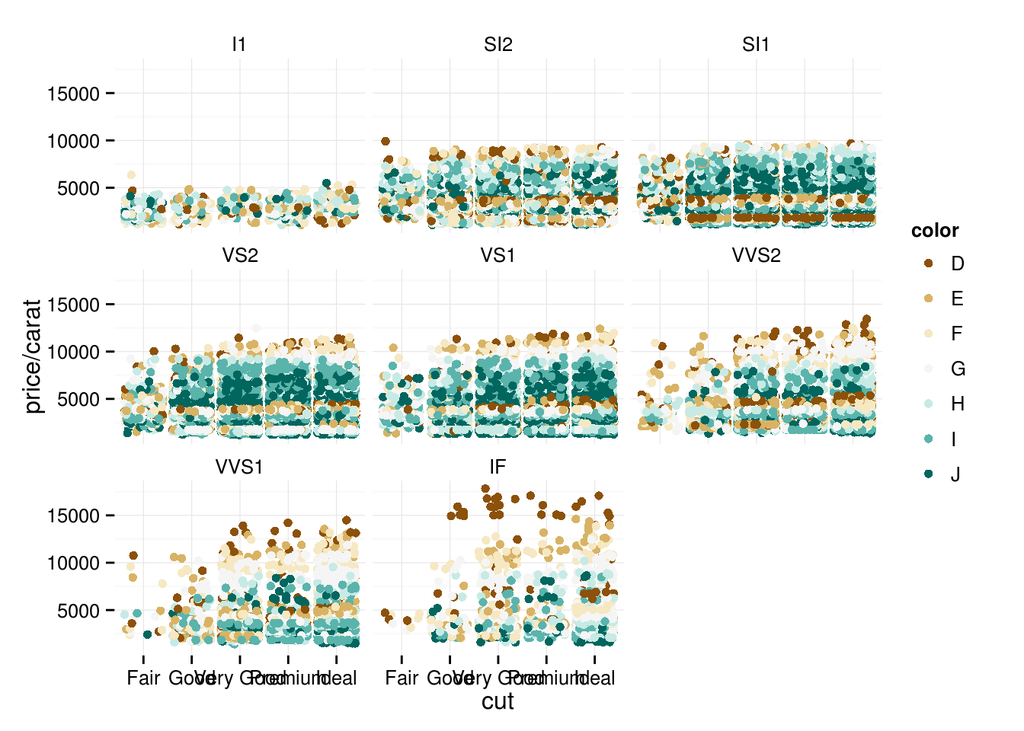

```r
# Create a scatter plot of the price/carat ratio of diamonds.
# The variable x should be assigned to cut.
# The points should be colored by diamond color,
# and the plot should be faceted by clarity.

# The plot should look something like this.
# http://i.imgur.com/YzbWkHT.jpg.

# Note: In the link, a color palette of type 'div' was used to color the histogram using
# scale_color_brewer(type = 'div')

ggplot(aes(x = cut, y = price/carat), data = diamonds) +
  #geom_point(aes(color = color)) +
  # use geom_jitter to spread the values inside single color bucket
  geom_jitter(aes(color = color), alpha = 1, position = position_jitter(h = 0)) +
  facet_wrap(~ clarity) +
  scale_color_brewer(type = 'div')
```

Observations:

- there is a trend to increase the price as the cut (x-axis) gets better
- there is more diamonds with middle-type clarity (SI2, SII, VS2), than bad ones (I1) and best (WS1, IF)
- for given cut and clarity there are ‘levels’ of prices (visible e.g. for D colours in each bar)

## Gapminder Multivariate Analysis

Gapminder data: http://www.gapminder.org/data/

In your investigation, examine 3 or more variables and create 2-5 plots that make use of the techniques from Lesson 5.

```r
# scatter/line plot of GDP and education level of population, male and female
library(openxlsx)
library(tidyr)
literacy_total <- read.xlsx('indicator SE_ADT_LITR_ZS.xlsx', rowNames = TRUE)
literacy_total <- mutate(literacy_total, country = rownames(literacy_total))
literacy_total <- gather(literacy_total, year, "literacy.total", 1:(length(literacy_total)-1), convert=TRUE)
literacy_total <- arrange(literacy_total, country, year)
literacy_total <- subset(literacy_total, !is.na(literacy_total$literacy.total))

literacy_male = read.xlsx('indicator SE_ADT_LITR_MA_ZS.xlsx', rowNames = TRUE)
literacy_male <- mutate(literacy_male, country = rownames(literacy_male))
literacy_male <- gather(literacy_male, year, "literacy.male", 1:(length(literacy_male)-1), convert=TRUE)
literacy_male <- arrange(literacy_male, country, year)
literacy_male <- subset(literacy_male, !is.na(literacy_male$literacy.male))

literacy_female = read.xlsx('indicator SE_ADT_LITR_FE_ZS.xlsx', rowNames = TRUE)
literacy_female <- mutate(literacy_female, country = rownames(literacy_female))
literacy_female <- gather(literacy_female, year, "literacy.female", 1:(length(literacy_female)-1), convert=TRUE)
literacy_female <- arrange(literacy_female, country, year)
literacy_female <- subset(literacy_female, !is.na(literacy_female$literacy.female))

income <- read.xlsx('indicator gapminder gdp_per_capita_ppp.xlsx', rowNames = TRUE, rows=1:260)
income <- mutate(income, country=rownames(income))
income <- gather(income, year, "income", 1:(length(income)-1), convert = TRUE)
income <- arrange(income, country, year)

lit_inc <- inner_join(income, literacy_total, by = c("country", "year"))
lit_inc <- inner_join(lit_inc, literacy_male, by = c("country", "year"))
lit_inc <- inner_join(lit_inc, literacy_female, by = c("country", "year"))
lit_inc$country.fact = factor(lit_inc$country)
```

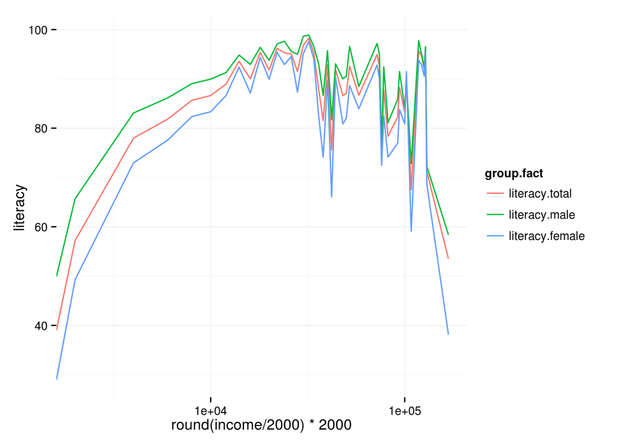

```r
lit_inc2 <- gather(lit_inc, "group", "literacy", 4:6)
lit_inc2$group.fact = factor(lit_inc2$group)
ggplot(aes(x = round(income/2000)*2000, y = literacy), data = lit_inc2) +
  geom_line(aes(color = group.fact), stat = 'summary', fun.y = mean) +
  scale_x_log10()
```

Observations:

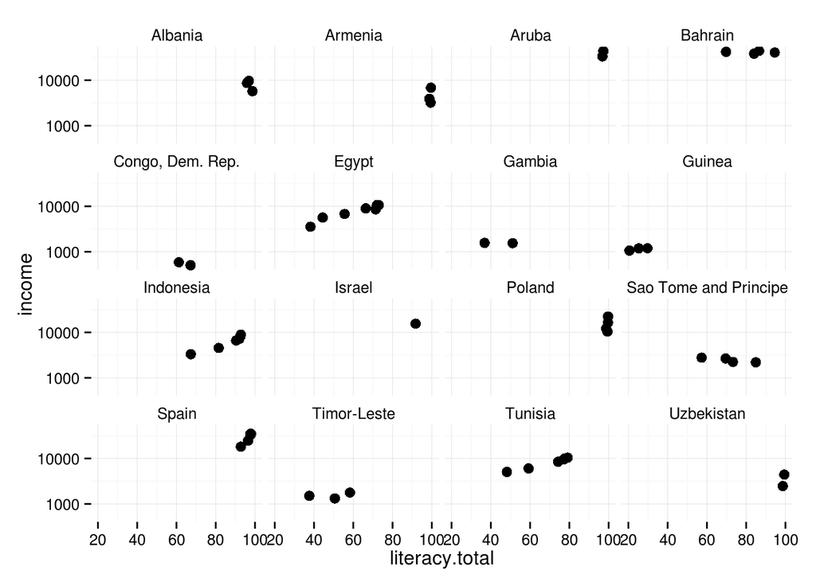

```r
set.seed(4000)
sample.countries <- sample(levels(lit_inc$country.fact), 16)
ggplot(aes(x = literacy.total, y = income), data = subset(lit_inc, country %in% sample.countries)) +
  geom_point(size = 3) +
  scale_y_log10() +
  #scale_color_brewer(type = 'div', palette = 3)
  facet_wrap(~ country.fact)
```

Observations: